# Replicating NYT Weather App

data-visualization

So much time since my last post so I want to post something, no matter what it is, but I hope this will be somehow helpful.

Joshua Kunst http://jkunst.com/  
12-02-2016

So much time since my last post so I want to post something, no matter what it is, but I hope this will be somehow helpfull

In this post I will show some new features for the next version of `highcharter` package. The main feature added is `hc_add_series` now is a **generic** function! This mean you can add the `data` argument can be numeric, data frame, time series (ts, xts, ohlc) amonth others so the syntaxis will be a little cleaner.

What we’ll do here? We’ll make an interactive version of the *well-well-know-and-a-little-repeated* Tufte weather chart.

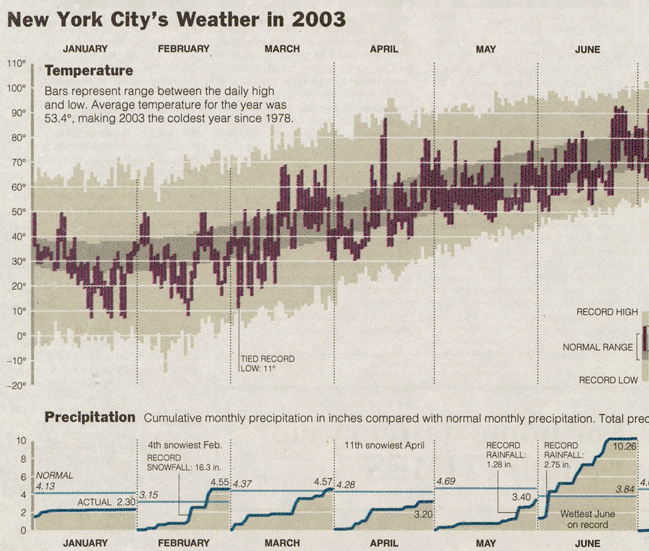

There are good ggplot versions if you can start https://rpubs.com/tyshynsk/133318 and https://rpubs.com/bradleyboehmke/weather_graphic.

But our focus will be replicate the New York Time App: [**How Much Warmer Was Your City in 2015?**](http://www.nytimes.com/interactive/2016/02/19/us/2015-year-in-weather-temperature-precipitation.html) where you can choose among **over 3K cities**!. So let’s start. So we need a interactive charting library and shiny.

## Data

If you search/explore in the devTools in the previous link you can know where is the path of the used data. So to be clear:

> All the data used in this post is from http://www.nytimes.com – Me.

We’ll load the `tidyverse`, download the data, and create an auxiliar variable `dt` to store the date time in numeric format.

```
library(tidyverse)
library(highcharter)
library(lubridate)

url_base <- "http://graphics8.nytimes.com/newsgraphics/2016/01/01/weather/assets"
file <- "new-york_ny.csv" # "san-francisco_ca.csv"
url_file <- file.path(url_base, file)

data <- read_csv(url_file)
data <- mutate(data, dt = datetime_to_timestamp(date))

data
```

```
# A tibble: 365 x 20
   date       month temp_max temp_min temp_rec_max temp_rec_min
   <date>     <dbl>    <dbl>    <dbl>        <dbl>        <dbl>
 1 2015-01-01     1       39       27           62           -4
 2 2015-01-02     1       42       35           68            2
 3 2015-01-03     1       42       33           64           -4
 4 2015-01-04     1       56       41           66           -3
 5 2015-01-05     1       49       21           64           -4
 6 2015-01-06     1       22       19           72           -2
 7 2015-01-07     1       23        9           64            4
 8 2015-01-08     1       21        8           65            2
 9 2015-01-09     1       33       19           64           -1
10 2015-01-10     1       23       16           60           -6
# ... with 355 more rows, and 14 more variables: temp_avg_max <dbl>,
#   temp_avg_min <dbl>, temp_rec_high <chr>, temp_rec_low <chr>,
#   precip_value <dbl>, precip_actual <dbl>, precip_normal <dbl>,
#   precip_rec <chr>, snow_rec <chr>,
#   annual_average_temperature <dbl>, departure_from_normal <dbl>,
#   total_precipitation <dbl>,
#   precipitation_departure_from_normal <dbl>, dt <dbl>
```

## Setup

Due the data is ready we’ll start to create the chart (a highchart object):

```
hc <- highchart() %>%
  hc_xAxis(
    type = "datetime",
    showLastLabel = FALSE,
    dateTimeLabelFormats = list(month = "%B")
  ) %>%
  hc_tooltip(
    shared = TRUE,
    useHTML = TRUE,
    headerFormat = as.character(tags$small("{point.x: %b %d}", tags$br()))
  ) %>%
  hc_plotOptions(series = list(borderWidth = 0, pointWidth = 4))

hc
```

[interactive chart not shown]

> *Nothing*. All acording to the plan XD.

## Temperatures

We’ll select the temperature columns from the data and do some wrangling, gather, spread, separate and recodes to get a nice **tidy data frame**.

```
dtempgather <- data %>%
  select(dt, starts_with("temp")) %>%
  select(-temp_rec_high,-temp_rec_low) %>%
  rename(temp_actual_max = temp_max,
         temp_actual_min = temp_min) %>%
  gather(key, value,-dt) %>%
  mutate(key = str_replace(key, "temp_", ""))

dtempspread <- dtempgather %>%
  separate(key, c("serie", "type"), sep = "_") %>%
  spread(type, value)

temps <- dtempspread %>%
  mutate(
    serie = factor(serie, levels = c("rec", "avg", "actual")),
    serie = fct_recode(
      serie,
      Record = "rec",
      Normal = "avg",
      Observed = "actual"
    )
  )

temps
```

```
# A tibble: 1,095 x 4
              dt serie      max   min
           <dbl> <fct>    <dbl> <dbl>
 1 1420070400000 Observed    39    27
 2 1420070400000 Normal      39    28
 3 1420070400000 Record      62    -4
 4 1420156800000 Observed    42    35
 5 1420156800000 Normal      39    28
 6 1420156800000 Record      68     2
 7 1420243200000 Observed    42    33
 8 1420243200000 Normal      39    28
 9 1420243200000 Record      64    -4
10 1420329600000 Observed    56    41
# ... with 1,085 more rows
```

Now whe can add this data to the *highchart* object using `hc_add_series`:

```
hc <- hc %>%
  hc_add_series(
    temps,
    type = "columnrange",
    hcaes(dt, low = min, high = max, group = serie),
    color = c("#ECEBE3", "#C8B8B9", "#A90048")
  )

hc
```

[interactive chart not shown]

A really similar chart of what we want!

The original chart show records of temprerature. So we need to filter the days with temperature records using the columns `temp_rec_high` and `temp_rec_low`, then some gathers and tweaks. Then set some options to show the points, like use fill color and some longer radius.

```
records <- data %>%
  select(dt, temp_rec_high, temp_rec_low) %>%
  filter(temp_rec_high != "NULL" | temp_rec_low != "NULL") %>%
  mutate_if(is.character, str_extract, "\\d+") %>%
  mutate_if(is.character, as.numeric) %>%
  gather(type, value,-dt) %>%
  filter(!is.na(value)) %>%
  mutate(type = str_replace(type, "temp_rec_", ""),
         type = paste("This year record", type))

pointsyles <- list(
  symbol = "circle",
  lineWidth = 1,
  radius = 4,
  fillColor = "#FFFFFF",
  lineColor = NULL
)

records
```

```
# A tibble: 9 x 3
             dt type                  value
          <dbl> <chr>                 <dbl>
1 1439769600000 This year record high    95
2 1441670400000 This year record high    97
3 1446768000000 This year record high    74
4 1449964800000 This year record high    67
5 1450051200000 This year record high    67
6 1450137600000 This year record high    68
7 1450915200000 This year record high    72
8 1451001600000 This year record high    66
9 1424390400000 This year record low      2
```

```
hc <- hc %>%
  hc_add_series(records, "point", hcaes(x = dt, y = value, group = type),
                marker = pointsyles)

hc
```

[interactive chart not shown]

We’re good.

## Precipitation

A nice feture of the NYTs app is and the chart is show the precipitaion by month. This data is in other axis. So we need to create a list with 2 axis using the `create_yaxis` helper and the adding this axis to the chart.

```
axis <- create_yaxis(
  naxis = 2,
  heights = c(3, 1),
  sep = 0.05,
  turnopposite = FALSE,
  showLastLabel = FALSE,
  startOnTick = FALSE
)
```

Manually add titles (I know this can be more elegant) and options.

```
axis[[1]]$title <- list(text = "Temperature")
axis[[1]]$labels <- list(format = "{value}ºF"))

axis[[2]]$title <- list(text = "Precipitation")
axis[[2]]$min <- 0

hc <- hc_yAxis_multiples(hc, axis)

hc
```

[interactive chart not shown]

The 2 axis are ready, now we need add the data. We will add 12 series -one for each month- but we want to asociate 1 legend for all these 12 series, so we need to use `id` and `linkedTo` parameters and obviously. That’s why the `id` will be a `'p'` for the firt element and then NA to the other 11. And then linked this 11 to the first series (`id = 'p'`).

```
precip <- select(data, dt, precip_value, month)

hc <- hc %>%
  hc_add_series(
    precip,
    type = "area",
    hcaes(dt, precip_value, group = month),
    name = "Precipitation",
    color = "#008ED0",
    lineWidth = 1,
    yAxis = 1,
    fillColor = "#EBEAE2",
    id = c("p", rep(NA, 11)),
    linkedTo = c(NA, rep("p", 11))
  )
```

The same way we’ll add the normal precipitations by month.

```
precipnormal <- data %>%
  select(dt, precip_normal, month) %>%
  group_by(month) %>%
  filter(row_number() %in% c(1, n())) %>%
  ungroup() %>%
  fill(precip_normal)

hc <- hc %>%
  hc_add_series(
    precipnormal,
    "line",
    hcaes(x = dt, y = precip_normal, group = month),
    name = "Normal Precipitation",
    color = "#008ED0",
    yAxis = 1,
    id = c("np", rep(NA, 11)),
    linkedTo = c(NA, rep("np", 11)),
    lineWidth = 1
  )
```

## Final Result

Curious how the chart looks? Me too! Nah, I saw the chart before this post.

```
hc
```

[interactive chart not shown]

## Shiny App

With R you can create a press style chart with some wrangling and charting. Now with a little of love we can make the code resuable to make a shiny app.

[interactive chart not shown]

Someone put the grid lines for the 2 axis as the original NYT app please to these charts! I will grateful if someone code that details.

See you :B!

[interactive chart not shown]

[via GIPHY](https://giphy.com/gifs/pam-pamlovesferrariboys-napkinapocalypse-xT0GqGrvB5PgQYSKGc)